# Combined Analysis of HFD/NCD Dexamethasone Adipose qPCR results

Innocence Harvey and Dave Bridges

July 3, 2015

This script uses the files in ../../data/raw/iWAT Combined qPCR Analysis.xlsx and used the worksheet Sheet2. These data are located in /Users/davebrid/Documents/GitHub/CushingAcromegalyStudy/scripts/scripts-obesity and this script was most recently run on Wed Aug 16 15:35:39 2017.

# Pnpla2

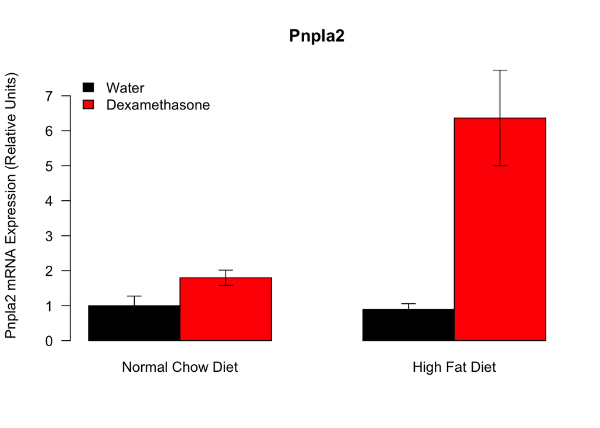

## Statistics - Pnpla2

From a two-way ANOVA with an interaction, the interaction term was significant (p=0.022):

ANOVA for Pnpla2 Expression

|  | Df | Sum Sq | Mean Sq | F value | Pr(>F) |
| --- | --- | --- | --- | --- | --- |
| Food | 1 | 0.10 | 0.10 | 6.31 | 0.01723 |
| Treatment | 1 | 0.25 | 0.25 | 15.05 | 0.00049 |
| Food:Treatment | 1 | 0.10 | 0.10 | 5.79 | 0.02201 |
| Residuals | 32 | 0.53 | 0.02 | NA | NA |

Tukey’s tests (pairwise comparasons are):

Tukey’s HSD tests for Pnpla2 Expression

|  | diff | lwr | upr | p adj |
| --- | --- | --- | --- | --- |
| High Fat Diet:Water-Normal Chow Diet:Water | 0.00 | -0.18 | 0.17 | 0.999846 |
| Normal Chow Diet:Dexamethasone-Normal Chow Diet:Water | 0.04 | -0.15 | 0.22 | 0.952663 |
| High Fat Diet:Dexamethasone-Normal Chow Diet:Water | 0.24 | 0.07 | 0.42 | 0.003205 |
| Normal Chow Diet:Dexamethasone-High Fat Diet:Water | 0.04 | -0.12 | 0.21 | 0.904593 |
| High Fat Diet:Dexamethasone-High Fat Diet:Water | 0.25 | 0.10 | 0.40 | 0.000424 |
| High Fat Diet:Dexamethasone-Normal Chow Diet:Dexamethasone | 0.21 | 0.05 | 0.37 | 0.006348 |

# Hsd11b1

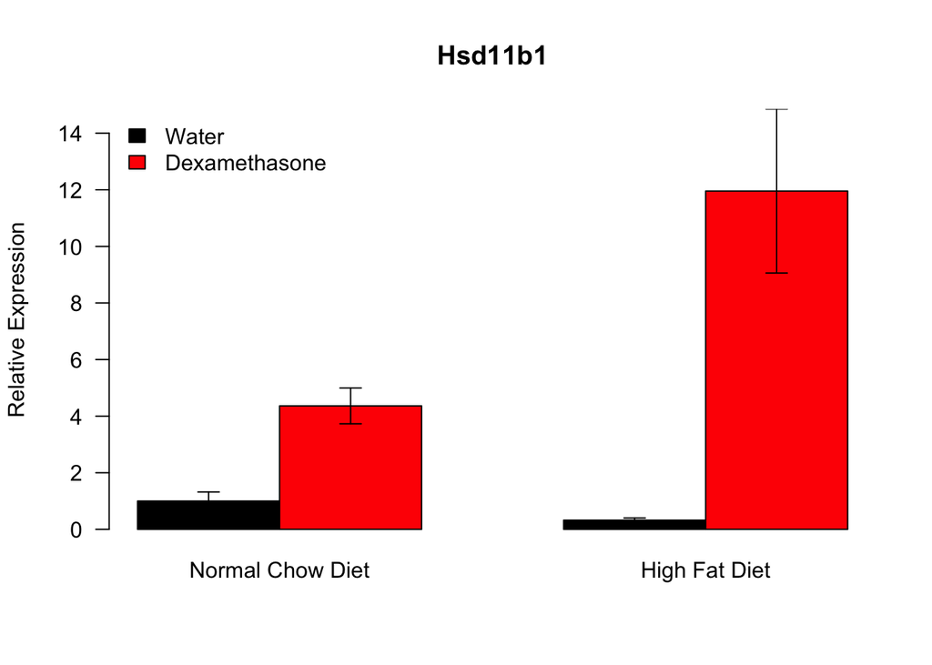

## Statistics - Hsd11b1

From a two-way ANOVA with an interaction, the interaction term was not quite significant (p=0.052):

ANOVA for Hsd11b1 Expression

|  | Df | Sum Sq | Mean Sq | F value | Pr(>F) |
| --- | --- | --- | --- | --- | --- |
| Food | 1 | 0.57 | 0.57 | 3.39 | 0.07499 |
| Treatment | 1 | 3.03 | 3.03 | 17.85 | 0.00019 |
| Food:Treatment | 1 | 0.69 | 0.69 | 4.06 | 0.05237 |
| Residuals | 32 | 5.43 | 0.17 | NA | NA |

Tukey’s tests (pairwise comparasons are):

Tukey’s HSD tests for Hsd11b1 Expression

|  | diff | lwr | upr | p adj |
| --- | --- | --- | --- | --- |
| High Fat Diet:Water-Normal Chow Diet:Water | -0.05 | -0.62 | 0.53 | 0.996163 |
| Normal Chow Diet:Dexamethasone-Normal Chow Diet:Water | 0.23 | -0.37 | 0.84 | 0.724094 |
| High Fat Diet:Dexamethasone-Normal Chow Diet:Water | 0.76 | 0.20 | 1.32 | 0.004504 |
| Normal Chow Diet:Dexamethasone-High Fat Diet:Water | 0.28 | -0.25 | 0.81 | 0.490361 |
| High Fat Diet:Dexamethasone-High Fat Diet:Water | 0.80 | 0.33 | 1.28 | 0.000393 |
| High Fat Diet:Dexamethasone-Normal Chow Diet:Dexamethasone | 0.53 | 0.02 | 1.03 | 0.041270 |

# Lipe

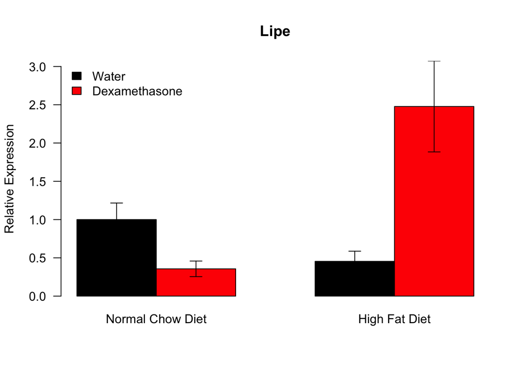

## Statistics - Lipe

From a two-way ANOVA with an interaction, the interaction term was significant (p=0.004).

ANOVA for Lipe Expression

|  | Df | Sum Sq | Mean Sq | F value | Pr(>F) |
| --- | --- | --- | --- | --- | --- |
| Food | 1 | 0 | 0 | 4.68 | 0.0381 |
| Treatment | 1 | 0 | 0 | 5.60 | 0.0241 |
| Food:Treatment | 1 | 0 | 0 | 9.56 | 0.0041 |
| Residuals | 32 | 0 | 0 | NA | NA |

Tukey’s tests (pairwise comparasons are):

Tukey’s HSD tests for Lipe Expression

|  | diff | lwr | upr | p adj |
| --- | --- | --- | --- | --- |
| High Fat Diet:Water-Normal Chow Diet:Water | 0.00 | -0.01 | 0.01 | 0.83281 |
| Normal Chow Diet:Dexamethasone-Normal Chow Diet:Water | 0.00 | -0.02 | 0.01 | 0.77715 |
| High Fat Diet:Dexamethasone-Normal Chow Diet:Water | 0.01 | 0.00 | 0.02 | 0.10545 |
| Normal Chow Diet:Dexamethasone-High Fat Diet:Water | 0.00 | -0.01 | 0.01 | 0.99838 |
| High Fat Diet:Dexamethasone-High Fat Diet:Water | 0.01 | 0.00 | 0.02 | 0.00348 |
| High Fat Diet:Dexamethasone-Normal Chow Diet:Dexamethasone | 0.01 | 0.00 | 0.02 | 0.00412 |

# Lpl

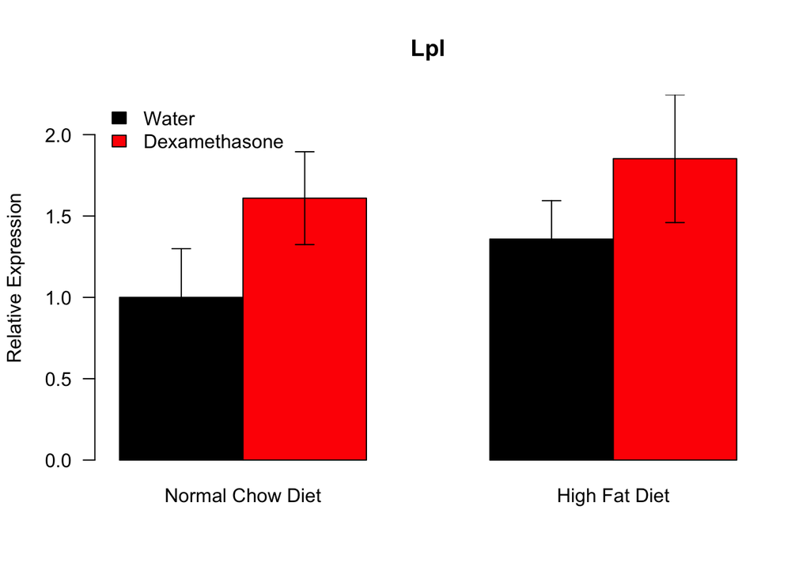

## Statistics - Lpl

From a two-way ANOVA with an interaction, the interaction term was not significant (p=0.869).

The ANOVA results are:

ANOVA for Lpl Expression

|  | Df | Sum Sq | Mean Sq | F value | Pr(>F) |
| --- | --- | --- | --- | --- | --- |
| Food | 1 | 4.74 | 4.74 | 0.66 | 0.424 |
| Treatment | 1 | 18.28 | 18.28 | 2.53 | 0.121 |
| Food:Treatment | 1 | 0.20 | 0.20 | 0.03 | 0.869 |
| Residuals | 32 | 231.19 | 7.22 | NA | NA |

ANOVA for Lpl Expression, No Interaction Term

|  | Df | Sum Sq | Mean Sq | F value | Pr(>F) |
| --- | --- | --- | --- | --- | --- |
| Food | 1 | 4.74 | 4.74 | 0.68 | 0.417 |
| Treatment | 1 | 18.28 | 18.28 | 2.61 | 0.116 |
| Residuals | 33 | 231.39 | 7.01 | NA | NA |

# IL6

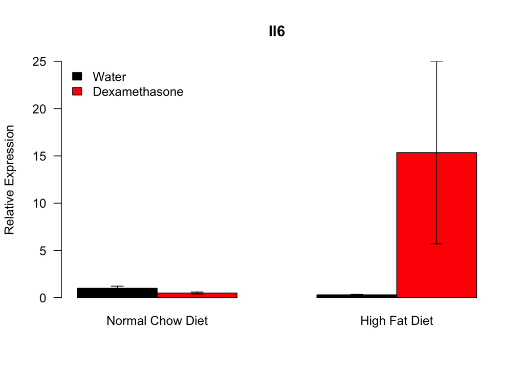

## Statistics - IL6

ANOVA for Il6 Expression

|  | Df | Sum Sq | Mean Sq | F value | Pr(>F) |
| --- | --- | --- | --- | --- | --- |
| Food | 1 | 353 | 353 | 1.89 | 0.18 |
| Treatment | 1 | 480 | 480 | 2.58 | 0.12 |
| Food:Treatment | 1 | 479 | 479 | 2.57 | 0.12 |
| Residuals | 28 | 5219 | 186 | NA | NA |

Tukey’s tests (pairwise comparasons are):

Tukey’s HSD tests for Il6 Expression

|  | diff | lwr | upr | p adj |
| --- | --- | --- | --- | --- |
| High Fat Diet:Water-Normal Chow Diet:Water | -0.69 | -19.48 | 18.1 | 1.000 |
| Normal Chow Diet:Dexamethasone-Normal Chow Diet:Water | -0.50 | -19.79 | 18.8 | 1.000 |
| High Fat Diet:Dexamethasone-Normal Chow Diet:Water | 14.35 | -4.94 | 33.6 | 0.201 |
| Normal Chow Diet:Dexamethasone-High Fat Diet:Water | 0.19 | -17.92 | 18.3 | 1.000 |
| High Fat Diet:Dexamethasone-High Fat Diet:Water | 15.04 | -3.07 | 33.2 | 0.130 |
| High Fat Diet:Dexamethasone-Normal Chow Diet:Dexamethasone | 14.85 | -3.79 | 33.5 | 0.155 |

# Nr3c1

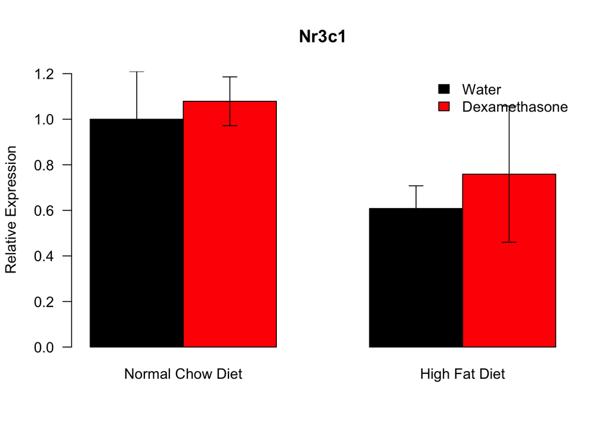

## Statistics - Nr3c1

ANOVA for Nr3c1 Expression

|  | Df | Sum Sq | Mean Sq | F value | Pr(>F) |
| --- | --- | --- | --- | --- | --- |
| Food | 1 | 1.05 | 1.05 | 3.58 | 0.0687 |
| Treatment | 1 | 0.11 | 0.11 | 0.37 | 0.5464 |
| Food:Treatment | 1 | 0.01 | 0.01 | 0.04 | 0.8528 |
| Residuals | 28 | 8.20 | 0.29 | NA | NA |

Tukey’s tests (pairwise comparasons are):

Tukey’s HSD tests for Nr3c1 Expression

|  | diff | lwr | upr | p adj |
| --- | --- | --- | --- | --- |
| High Fat Diet:Water-Normal Chow Diet:Water | -0.39 | -1.14 | 0.35 | 0.488 |
| Normal Chow Diet:Dexamethasone-Normal Chow Diet:Water | 0.08 | -0.69 | 0.84 | 0.992 |
| High Fat Diet:Dexamethasone-Normal Chow Diet:Water | -0.24 | -1.01 | 0.52 | 0.825 |
| Normal Chow Diet:Dexamethasone-High Fat Diet:Water | 0.47 | -0.25 | 1.19 | 0.299 |
| High Fat Diet:Dexamethasone-High Fat Diet:Water | 0.15 | -0.57 | 0.87 | 0.939 |
| High Fat Diet:Dexamethasone-Normal Chow Diet:Dexamethasone | -0.32 | -1.06 | 0.42 | 0.643 |

# Ucp1

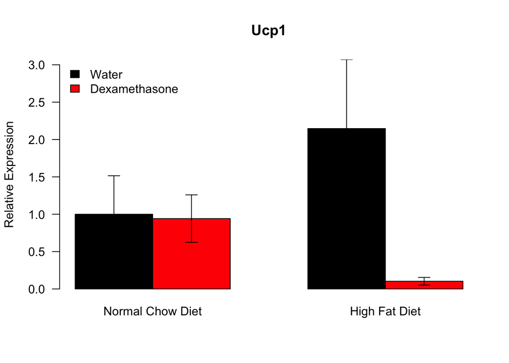

## Statistics - Ucp1

ANOVA for Ucp1 Expression

|  | Df | Sum Sq | Mean Sq | F value | Pr(>F) |
| --- | --- | --- | --- | --- | --- |
| Food | 1 | 0.37 | 0.37 | 0.13 | 0.7175 |
| Treatment | 1 | 9.88 | 9.88 | 3.53 | 0.0707 |
| Food:Treatment | 1 | 7.82 | 7.82 | 2.79 | 0.1058 |
| Residuals | 28 | 78.36 | 2.80 | NA | NA |

Tukey’s tests (pairwise comparasons are):

Tukey’s HSD tests for Ucp1 Expression

|  | diff | lwr | upr | p adj |
| --- | --- | --- | --- | --- |
| High Fat Diet:Water-Normal Chow Diet:Water | 1.15 | -1.15 | 3.45 | 0.5336 |
| Normal Chow Diet:Dexamethasone-Normal Chow Diet:Water | -0.06 | -2.42 | 2.31 | 0.9999 |
| High Fat Diet:Dexamethasone-Normal Chow Diet:Water | -0.90 | -3.26 | 1.47 | 0.7303 |
| Normal Chow Diet:Dexamethasone-High Fat Diet:Water | -1.21 | -3.42 | 1.01 | 0.4607 |
| High Fat Diet:Dexamethasone-High Fat Diet:Water | -2.04 | -4.26 | 0.18 | 0.0795 |
| High Fat Diet:Dexamethasone-Normal Chow Diet:Dexamethasone | -0.84 | -3.12 | 1.45 | 0.7496 |

# Foxo3

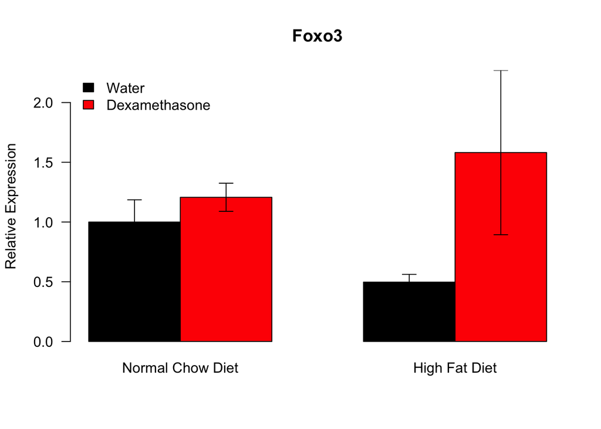

## Statistics - Foxo3

|  | Df | Sum Sq | Mean Sq | F value | Pr(>F) |
| --- | --- | --- | --- | --- | --- |
| Food | 1 | 0.08 | 0.08 | 0.08 | 0.7772 |
| Treatment | 1 | 3.61 | 3.61 | 3.49 | 0.0724 |
| Food:Treatment | 1 | 1.53 | 1.53 | 1.47 | 0.2347 |
| Residuals | 28 | 29.02 | 1.04 | NA | NA |

Tukey’s tests (pairwise comparasons are):

Tukey’s HSD tests for Foxo3 Expression

|  | diff | lwr | upr | p adj |
| --- | --- | --- | --- | --- |
| High Fat Diet:Water-Normal Chow Diet:Water | -0.50 | -1.90 | 0.90 | 0.762 |
| Normal Chow Diet:Dexamethasone-Normal Chow Diet:Water | 0.21 | -1.23 | 1.65 | 0.979 |
| High Fat Diet:Dexamethasone-Normal Chow Diet:Water | 0.58 | -0.86 | 2.02 | 0.690 |
| Normal Chow Diet:Dexamethasone-High Fat Diet:Water | 0.71 | -0.64 | 2.06 | 0.489 |
| High Fat Diet:Dexamethasone-High Fat Diet:Water | 1.08 | -0.27 | 2.44 | 0.150 |
| High Fat Diet:Dexamethasone-Normal Chow Diet:Dexamethasone | 0.37 | -1.02 | 1.76 | 0.882 |